# 03-07presentation

## Advanced Topic Modeling (Mar 31st)

#### Primary Libraries Used:

- [Pandas](https://pandas.pydata.org/docs/): Fast open source data analysis and manipulation tool
- [Gensim](https://radimrehurek.com/gensim/#): Fast open source library for unsupervised topic modeling
- [Spacy](https://spacy.io/): Open source library for advanced natural language processing

Primary data set: https://www.kaggle.com/datasets/snapcrack/all-the-news

143,000 articles from 15 major american publishers

Definitions:

- Corpus - a collection of written texts
- Doc - a text in a corpus
- Token - a word in a doc
- ngram - a contiguous sequence of n items from a given sample of text or speech

Structure:

- Data loading
- Data cleaning
- Data exploring
- Ngram building
- Doc building
- LDA Model training
- Analysing LDA Model

```python
import pandas as pd
import re # for regex handling
import warnings #QOL getting rid of warnings
from tqdm import tqdm # for build time
tqdm.pandas()
import matplotlib.pyplot as plt # plotting
from IPython.display import HTML
HTML('''<script>
code_show_err=false;
function code_toggle_err() {
 if (code_show_err){
 $('div.output_stderr').hide();
 } else {
 $('div.output_stderr').show();
 }
 code_show_err = !code_show_err
}
$( document ).ready(code_toggle_err);
</script>
To toggle on/off output_stderr, click <a href="javascript:code_toggle_err()">here</a>.''')
warnings.filterwarnings("ignore")
warnings.filterwarnings("ignore", category=DeprecationWarning)

article_df = pd.read_csv('newsArticles/articles1.csv')

# art2 = pd.read_csv('../data/newsArticles/articles2.csv')
# art3 = pd.read_csv('../data/newsArticles/articles3.csv')
# article_df = pd.concat([article_df,art2,art3])
```

```python
# some stats on the dataframe
nyt = article_df[article_df['publication'] == 'New York Times'][:3000] # grabbing the first 3000 NYT articles
BI = article_df[article_df['publication'] == 'Business Insider'][:3000]
BB = article_df[article_df['publication'] == 'Breitbart'][:3000]
article_df = pd.concat([nyt, BI, BB]) #joining all the articles
del nyt, BI, BB
article_df.head()

#now 9000 articles from 3 american publishers.
```

|  | Unnamed: 0 | id | title | publication | author | date | year | month | url | content |
| --- | --- | --- | --- | --- | --- | --- | --- | --- | --- | --- |
| 0 | 0 | 17283 | House Republicans Fret About Winning Their Hea... | New York Times | Carl Hulse | 2016-12-31 | 2016.0 | 12.0 | NaN | WASHINGTON — Congressional Republicans have... |
| 1 | 1 | 17284 | Rift Between Officers and Residents as Killing... | New York Times | Benjamin Mueller and Al Baker | 2017-06-19 | 2017.0 | 6.0 | NaN | After the bullet shells get counted, the blood... |
| 2 | 2 | 17285 | Tyrus Wong, ‘Bambi’ Artist Thwarted by Racial ... | New York Times | Margalit Fox | 2017-01-06 | 2017.0 | 1.0 | NaN | When Walt Disney’s “Bambi” opened in 1942, cri... |
| 3 | 3 | 17286 | Among Deaths in 2016, a Heavy Toll in Pop Musi... | New York Times | William McDonald | 2017-04-10 | 2017.0 | 4.0 | NaN | Death may be the great equalizer, but it isn’t... |
| 4 | 4 | 17287 | Kim Jong-un Says North Korea Is Preparing to T... | New York Times | Choe Sang-Hun | 2017-01-02 | 2017.0 | 1.0 | NaN | SEOUL, South Korea — North Korea’s leader, ... |

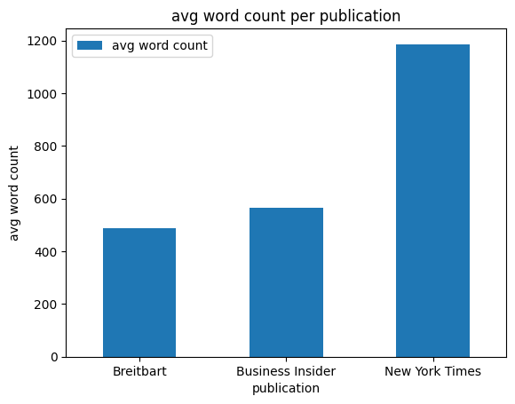

```python
# simple graph of avg word count per publication
wc = article_df[['publication', 'content', 'date']]
wc['word_count'] = wc.apply(lambda x: len(str(x['content']).split(" ")), axis=1)
#print(wc.groupby(['publication'])['word_count'].mean().reset_index().rename(columns={'word_count':'avg word count'}))

wa = wc.groupby(['publication'])['word_count'].mean().reset_index().rename(columns={'word_count':'avg word count'})
ax = wa.plot.bar(x='publication', y='avg word count')
plt.ylabel('avg word count')
plt.title('avg word count per publication')
plt.xticks(rotation=0)

del wc, wa, ax
```

Text Pre-Processing

```python
def text_clean(text):
    return re.sub('(\W+)', " ", text).lower() # replaces all non-word characters with a space and sets it to lower

# joining all text data (title, publication, author etc.) and removing all non-word chars
article_str_df = article_df[['title', 'publication', 'author', 'content']]
article_str_df['contentCL'] = article_str_df['title'].astype('str') + " "+ \
                              article_str_df['publication'].astype('str') + " "+\
                              article_str_df['author'].astype('str') +" "+ \
                              article_str_df['content'] # joining all text data in to one col
article_str_df['contentCL'] = article_str_df['contentCL'].progress_apply(text_clean)

article_str_df[:5][['content', 'contentCL', "publication"]]
```

|  | content | contentCL | publication |
| --- | --- | --- | --- |
| 0 | WASHINGTON — Congressional Republicans have... | house republicans fret about winning their hea... | New York Times |
| 1 | After the bullet shells get counted, the blood... | rift between officers and residents as killing... | New York Times |
| 2 | When Walt Disney’s “Bambi” opened in 1942, cri... | tyrus wong bambi artist thwarted by racial bia... | New York Times |
| 3 | Death may be the great equalizer, but it isn’t... | among deaths in 2016 a heavy toll in pop music... | New York Times |
| 4 | SEOUL, South Korea — North Korea’s leader, ... | kim jong un says north korea is preparing to t... | New York Times |

Text Processing for Bag Of Words

- Tokenization: The process of splitting text into a list of words.

ex: "Trying is the first step toward failure." - Homer Simpson ["trying", "is", "the", "first", "step", "toward", "failure","."]

- Lemmatization: converting a word into a standardized form based off of the context, called a Lemma.

ex: Caring -> Care

```python
import spacy
nlp = spacy.load('en_core_web_sm')
#nlp.Defaults.stop_words

#isolating the cleaned text column
texts = list(article_str_df['contentCL'].reset_index().drop(columns='index')['contentCL'])

del article_str_df, article_df
```

```python
import itertools
import collections

def lemmatize_batch(docs):
    """
    using spacy lemma_ function to lemmatize the words in the docs and keep if not stop word
    Utalizing batching so we dont have to run nlp.pipe on the whole corpus.
    :param docs: list of documents
    :return: list of lists of lemmatized and cleaned tokens for each document
    """
    # Batch documents together
    docs = list(docs)
    batch_size = 1000
    batches = [docs[i:i+batch_size] for i in range(0, len(docs), batch_size)]

    # Process batches using spacy parser
    lemmatized_docs = []
    for batch in tqdm(batches):
        docs = nlp.pipe(batch)
        lemmatized_batch = []
        for doc in docs:
            lemmatized_tokens = [token.lemma_ for token in doc if not token.is_stop and len(str(token.lemma_)) > 3]
            lemmatized_batch.append(lemmatized_tokens)
        lemmatized_docs.extend(lemmatized_batch)

    return lemmatized_docs
```

```python
#lemmatizing corpus (longest process of the whole thing works in O(M*N) for M docs and N words assuming the
# lemmatization run time is o(1)
lemma_arr = lemmatize_batch(texts)

###### REMOVE LATER
# lemma_arr = pd.read_csv('lemma_csv.csv').rename(columns={'0':'val'}).\
#     apply(lambda x: x['val'].split(" "), axis=1).tolist()
#######
word_list = list(itertools.chain(*lemma_arr)) #flattening the corpus using itertools.chain to get a list of all words in the corpus
N = len(word_list) # total number of words in the corpus
counted_words = collections.Counter(word_list) # count for each word
```

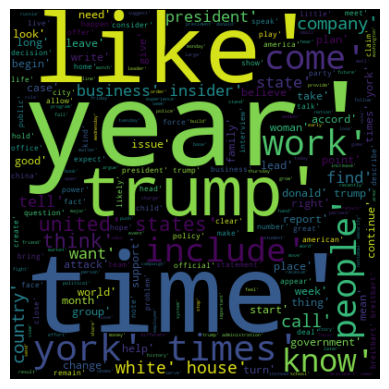

```python
from wordcloud import WordCloud
wordcloud_words = [str(p) for p in lemma_arr]
wordcloud_strings = ",".join(wordcloud_words)
wordcloud_words = WordCloud(background_color='black', width=400, height=400).generate(wordcloud_strings)


plt.imshow(wordcloud_words, interpolation='bilinear')
plt.axis('off')
plt.show()
#counted_words.most_common(15)
del wordcloud_words, wordcloud_strings
```